# Data driven retail chain expansion - Location Analytics

## Objective

- Analyse for optimal location for new bakery outlets in neighborhoods of the Chennai City
- Use various data science and analysis techniques to reach goal of selecting optimal locations.

## Data Acquisition

The data and their respective data sources for our projects are discussed below,

1. Chennai city's major areas and neighbourhood

   **Data Source:** [Wikipedia](https://en.wikipedia.org/wiki/Areas_of_Chennai)

   **Data description:** We will initialize crawler to scrape and extract data and information about the areas and locality from the wikipedia web page.
2. Geographical coordinate of the areas

   **Data Source:** Python's [geocoder library](https://geocoder.readthedocs.io/index.html)

   **Data description:** Geocoder is a simple and consistent geocoding library written in Python. Dealing with multiple different geocoding provider such as Google, Bing, OSM and many more. Specifically, we will be using ArcGIS, as it is reliable and free.
3. To get nearby venues in each locality of Chennai city,

   **Data Source:** [Google API](https://mapsplatform.google.com/maps-products/#places)

   **Data description:** This API allows us to get information about all the venues in the neighbourhood of Chennai City. Google Credentials is used to fetch the data.

#### Importing necessary modules

```python
# Prerequisites
!pip install pandas
!pip install geopy
!pip install geocoder -q
```

```python
import os
os.getcwd()

import numpy as np
import pandas as pd
import json
import time
import pickle

import requests
from bs4 import BeautifulSoup

from geopy.distance import geodesic
import geocoder
import geopy

from sklearn.cluster import KMeans
from sklearn.metrics import silhouette_score

import matplotlib.pyplot as plt

import warnings
warnings.filterwarnings("ignore")
```

#### Fetching neighborhoods - Wiki & geocoder

##### Web Scraping - Wikipedia

Wikipedia page has the neighborhood details. Using web scraping technique, we fetch the neighborhood details from the wiki page.

```python
url = "https://en.wikipedia.org/wiki/Areas_of_Chennai"
```

```python
r = requests.get(url)
soup = BeautifulSoup(r.text, "html.parser")
areas = soup.find('table', {'class': 'wikitable'}).find_all('a')
```

##### Geographical coordinates - Geocoder library

Geocoder is a simple and consistent geocoding library written in Python. Dealing with multiple different geocoding provider such as Google, Bing, OSM and many more. Specifically, we will be using ArcGIS, as it is reliable and free.

```python
# Finding lat,long of dataframe for each location using arcgis

chennai_df = pd.DataFrame()
for i, neighbor in enumerate(areas):
    print('\rProcessing:', i+1, end="")
    record = [neighbor.text.strip()]
    record.extend(geocoder.arcgis(f'{record[0]}, Chennai, Tamil Nadu, India').latlng)
    chennai_df = pd.concat([chennai_df,pd.DataFrame(record).T], ignore_index=True)

chennai_df.columns=['Neighborhood', 'Latitude', 'Longitude']
chennai_df.drop_duplicates('Neighborhood', inplace=True)
chennai_df.head()
```

```
Processing: 162
```

|  | Neighborhood | Latitude | Longitude |
| --- | --- | --- | --- |
| 0 | Adambakkam | 12.99192 | 80.20603 |
| 1 | Adyar | 13.00303 | 80.25187 |
| 2 | Alandur | 13.00013 | 80.20049 |
| 3 | Alapakkam | 13.04613 | 80.16501 |
| 4 | Alwarpet | 13.03471 | 80.25416 |

```python
chennai_df['District'] = "Chennai"
```

```python
len(chennai_df)
```

```
161
```

Save dataframe to pickle file & Load dataframe from pickle file

```python
path2 = os.getcwd() + '\\Data\\Pickle\\'
```

```python
with open(path2 + 'chennai_df.pkl', 'wb') as f:
    pickle.dump(chennai_df, f)
```

```python
with open(path2 + 'chennai_df.pkl', 'rb') as f:
    chennai_df = pickle.load(f)

chennai_df.head(2)
```

|  | Neighborhood | Latitude | Longitude |
| --- | --- | --- | --- |
| 0 | Adambakkam | 12.99192 | 80.20603 |
| 1 | Adyar | 13.00303 | 80.25187 |

#### Google Places API - Nearby search on Chennai

https://developers.google.com/maps/documentation/places/web-service/overview

```python
# Chennai - 13.0827° N, 80.2707° E

data = {'Neighborhood':['Chennai'],
        'Latitude':[13.0827],
        'Longitude':[80.2707]
       }

# Create DataFrame
location_df = pd.DataFrame(data)
```

```python
BASE_URL = "https://maps.googleapis.com/maps/api/place/nearbysearch/json?"
KEY = "ENTER API KEY"

type = 'post_office'

# Gathering the Data from the API https://maps.googleapis.com/maps/api/place/nearbysearch/json
the_venues = pd.DataFrame()

for i, r in location_df.iterrows():
    venues_list = []
    params = {}
    venues_baixo = []
    venues_name = []
    venues_lat = []
    venues_long = []
    venues_type = []
    venues_price_level = []
    venues_rating = []
    venues_n_ratings = []
    venues_vicinity = []
    TYPE = type
    venues_locality = location_df['Neighborhood'][0]

    venues_url = BASE_URL + f'location={location_df.Latitude[i]}%2C{location_df.Longitude[i]}&type={TYPE}&radius={200000}&key={KEY}'

    res = requests.get(venues_url, params = params)
    results = json.loads(res.content)
    venues_list.extend(results['results'])
    time.sleep(2)

    while "next_page_token" in results:
        params['pagetoken'] = results['next_page_token'],
        res = requests.get(venues_url, params = params)
        results = json.loads(res.content)
        venues_list.extend(results['results'])
        time.sleep(2)

    for i2 in range(len(venues_list)):
        venues = venues_list[i2]
        try:
            venues_name.append(venues['name'])
        except:
            venues_name.append('none')
        try:
            venues_type.append(venues['types'])
        except:
            venues_type.append('none')
        try:
            venues_lat.append(venues['geometry']['location']['lat'])
        except:
            venues_lat.append('none')
        try:
            venues_long.append(venues['geometry']['location']['lng'])
        except:
            venues_long.append('none')
        try:
            venues_price_level.append(venues['price_level'])
        except:
            venues_price_level.append('none')
        try:
            venues_rating.append(venues['rating'])
        except:
            venues_rating.append('none')
        try:
            venues_n_ratings.append(venues['user_ratings_total'])
        except:
            venues_n_ratings.append('none')
        try:
            venues_vicinity.append(venues['vicinity'])
        except:
            venues_vicinity.append('none')

        try:
            venues_baixo.append(baixos_df.Neighborhood[i])
        except:
            venues_baixo.append('none')

    df_dict = {'locality':venues_locality, 'name':venues_name, 'Latitude':venues_lat,
            'Longitude':venues_long, 'types':venues_type, 'price level':venues_price_level,
            'rating':venues_rating, 'total ratings':venues_n_ratings, 'vicinity':venues_vicinity, #'category': KEYWORD
            }
    venues_df = pd.DataFrame(df_dict)
    the_venues = the_venues.append(venues_df, ignore_index=True)

#the_venues.to_csv('all_venues.csv', index=False)
```

```python
the_venues.head()
```

|  | locality | name | Latitude | Longitude | types | price level | rating | total ratings | vicinity |
| --- | --- | --- | --- | --- | --- | --- | --- | --- | --- |
| 0 | Chennai | RMS India Post Office | 13.082229 | 80.275132 | [post_office, finance, point_of_interest, esta... | none | 3.9 | 12 | 37JG+V3R, Kannappar Thidal, Periyamet, Chennai |
| 1 | Chennai | Choolai Post Office | 13.090412 | 80.265550 | [post_office, finance, point_of_interest, esta... | none | 4.1 | 9 | 37R8+567, Tiru Narayana Guru Road, Choolai, Ch... |
| 2 | Chennai | Post Office - Egmore | 13.076375 | 80.262621 | [post_office, finance, point_of_interest, esta... | none | 3.7 | 12 | 37G7+H25, Kennet Lane, Egmore, Chennai |
| 3 | Chennai | India Post | 13.089860 | 80.259219 | [post_office, finance, point_of_interest, esta... | none | 3.7 | 6 | No. 69, 10, Kalathiappa Street, Choolai, Chennai |
| 4 | Chennai | India Post Superindent RMS | 13.074866 | 80.258819 | [post_office, finance, point_of_interest, esta... | none | 4 | 3 | 37F5+WGW, Police Commisioners Road, Egmore, Ch... |

##### Function for Google Places API - Nearby search with category

```python
# Google Places API key
BASE_URL = "https://maps.googleapis.com/maps/api/place/nearbysearch/json?"
KEY = "ENTER API KEY"
```

Desired categories:

- Petrolbunk, Theatre, School, Bakery, Government office, Gym, Salon

```python
def get_venues(location_df,loc_category):
    print('---')
    # Gathering the Data from the API https://maps.googleapis.com/maps/api/place/nearbysearch/json
    the_venues = pd.DataFrame()

    for i, r in location_df.iterrows():
        venues_list = []
        params = {}
        venues_baixo = []
        venues_name = []
        venues_lat = []
        venues_long = []
        venues_type = []
        venues_price_level = []
        venues_rating = []
        venues_n_ratings = []
        venues_vicinity = []
        TYPE = loc_category
        district = location_df['District'][0]

        venues_url = BASE_URL + f'location={location_df.Latitude[i]}%2C{location_df.Longitude[i]}&keyword={TYPE}&radius={1000}&key={KEY}'

        res = requests.get(venues_url, params = params)
        results = json.loads(res.content)
        venues_list.extend(results['results'])
        time.sleep(2)

        while "next_page_token" in results:
            params['pagetoken'] = results['next_page_token'],
            res = requests.get(venues_url, params = params)
            results = json.loads(res.content)
            venues_list.extend(results['results'])
            time.sleep(2)

        for i2 in range(len(venues_list)):
            venues = venues_list[i2]
            try:
                venues_name.append(venues['name'])
            except:
                venues_name.append('none')
            try:
                venues_type.append(venues['types'])
            except:
                venues_type.append('none')
            try:
                venues_lat.append(venues['geometry']['location']['lat'])
            except:
                venues_lat.append('none')
            try:
                venues_long.append(venues['geometry']['location']['lng'])
            except:
                venues_long.append('none')
            try:
                venues_price_level.append(venues['price_level'])
            except:
                venues_price_level.append('none')
            try:
                venues_rating.append(venues['rating'])
            except:
                venues_rating.append('none')
            try:
                venues_n_ratings.append(venues['user_ratings_total'])
            except:
                venues_n_ratings.append('none')
            try:
                venues_vicinity.append(venues['vicinity'])
            except:
                venues_vicinity.append('none')

            try:
                venues_baixo.append(location_df.Neighborhood[i])
            except:
                venues_baixo.append('none')

        df_dict = {'district':district ,'locality':venues_baixo, 'name':venues_name, 'latitude':venues_lat,
                'longitude':venues_long, 'types':venues_type, 'price level':venues_price_level,
                'rating':venues_rating, 'total ratings':venues_n_ratings, 'vicinity':venues_vicinity, 'category': TYPE
                }
        venues_df = pd.DataFrame(df_dict)
        the_venues = the_venues.append(venues_df, ignore_index=True)

    print('Extracted ', TYPE,": " ,len(the_venues))
    return the_venues

#the_venues.to_csv('all_venues.csv', index=False)
```

```python
# petrolbunk, theatre, school, bakery, governmentoffice, gym, salon

def get_venues_categories(df):
    df_sch = get_venues(df,'school')
    df_bk = get_venues(df,'bakery')
    df_pet = get_venues(df,'petrolbunk')
    df_th = get_venues(df,'theatre')
    df_gov = get_venues(df,'governmentoffice')
    df_gym = get_venues(df,'gym')
    df_sln = get_venues(df,'salon')

    df_venues = pd.concat([df_sch,df_bk,df_pet,df_th,df_gov,df_gym,df_sln],axis=0)
    return df_venues
```

```python
df_chennai1 = chennai_df.head(2)
```

##### Prepare dataset with venues

```python
len(chennai_df)
```

```
161
```

```python
# Split dataframe into chunks
n = 50  #chunk row size
list_df = [chennai_df[i:i+n] for i in range(0,len(chennai_df),n)]
```

```python
# Split dataframe into chunks
df_chennai_set1 = list_df[0].reset_index(drop=True)
df_chennai_set2 = list_df[1].reset_index(drop=True)
df_chennai_set3 = chennai_df.iloc[100:180].reset_index(drop=True)
```

```python
# time for extraction depends of radius of area
df_venues_chennai_set1 = get_venues_catgeroies(df_chennai_set1)
```

```
---
Extracted  school :  3000
---
Extracted  bakery :  2954
---
Extracted  petrolbunk :  2576
---
Extracted  theatre :  2259
---
Extracted  governmentoffice :  2831
---
Extracted  gym :  2778
---
Extracted  salon :  2814
```

```python
df_venues_chennai_set2 = get_venues_catgeroies(df_chennai_set2)
```

```
---
Extracted  school :  3000
---
Extracted  bakery :  2965
---
Extracted  petrolbunk :  2495
---
Extracted  theatre :  1794
---
Extracted  governmentoffice :  2875
---
Extracted  gym :  2817
---
Extracted  salon :  2789
```

```python
df_venues_chennai_set3 = get_venues_catgeroies(df_chennai_set3)
```

```
---
Extracted  school :  3637
---
Extracted  bakery :  3587
---
Extracted  petrolbunk :  3113
---
Extracted  theatre :  2367
---
Extracted  governmentoffice :  3559
---
Extracted  gym :  3476
---
Extracted  salon :  3468
```

```python
# Write each set to csv

#df_venues_chennai_set1.to_csv('chennai_set1_venues.csv', index=False)
#df_venues_chennai_set2.to_csv('chennai_set2_venues.csv', index=False)
#df_venues_chennai_set3.to_csv('chennai_set3_venues.csv', index=False)
```

```python
# Length of dataframes
print(len(df_venues_chennai_set1), #16569
len(df_venues_chennai_set2), #16761
len(df_venues_chennai_set3)) #26291
```

```
19212 18735 23207
```

```python
# Read from csv

#df_venues_chennai_set1 = pd.read_csv(path1 + 'chennai_set1_venues.csv')
#df_venues_chennai_set2 = pd.read_csv(path1 + 'chennai_set2_venues.csv')
#df_venues_chennai_set3 = pd.read_csv(path1 + 'chennai_set3_venues.csv')
```

```python
# Concat all set into one dataframe
df_venues = pd.concat([df_venues_chennai_set1,df_venues_chennai_set2,df_venues_chennai_set3],axis=0)
```

```python
# Write to csv
#df_venues.to_csv('df_venues_chennai.csv', index=False)
```

##### Remove duplicates from same location in two rounds

```python
# Round 1 - Same venue with same lat,long
duplicate_venues = df_venues.groupby(['name','latitude','longitude']).size().reset_index(name='count')
duplicate_venues[duplicate_venues['count']!=1]
```

|  | name | latitude | longitude | count |
| --- | --- | --- | --- | --- |
| 0 | #hashtag salon | 13.055346 | 80.161262 | 2 |
| 1 | (BSB) SRI BALAJI SWEETS AND BAKERY | 13.134110 | 80.141261 | 3 |
| 2 | (பால்வளத்துறை) Commissionerate of Dairy Develo... | 13.154288 | 80.242649 | 2 |
| 3 | 10 FITNESS LABORATORY | 13.038973 | 80.257608 | 10 |
| 4 | 10 Muffins (Organic and Healthy Bakery & Cafe) | 12.910495 | 80.202375 | 10 |
| ... | ... | ... | ... | ... |
| 7246 | ஶ்ரீ ராம் நகர் பால்வடி | 13.198191 | 80.135687 | 2 |
| 7247 | ஸ்ரீராம் ஸ்டோர்ஸ் | 13.160642 | 80.120298 | 3 |
| 7248 | 𝑇&𝑇 𝐻𝐴𝐼𝑅𝐷𝑅𝐸𝑆𝑆𝐼𝑁𝐺 𝑈𝑛𝑖𝑠𝑒𝑥 𝑆𝑎𝑙𝑜𝑛 | 12.966859 | 80.149320 | 4 |
| 7249 | 𝑫𝑶𝑵 𝑩𝑶𝑺𝑪𝑶 𝑴𝑨𝑻𝑹𝑰𝑪𝑼𝑳𝑨𝑻𝑰𝑶𝑵 𝑺𝑪𝑯𝑶𝑶𝑳, 𝑲.𝑲.𝑫 𝑵𝑨𝑮𝑨𝑹 | 13.131506 | 80.259236 | 8 |
| 7252 | 💒Infant Jesus Matriculation Higher Secondary S... | 13.130712 | 80.208809 | 18 |

5618 rows × 4 columns

```python
# Check after removing duplicates
df_venues.drop_duplicates(['name','latitude','longitude'], ignore_index=True) \
            .groupby(['name','latitude','longitude']).size().reset_index(name='count') \
            .sort_values(by='count',ascending=False).head()
```

|  | name | latitude | longitude | count |
| --- | --- | --- | --- | --- |
| 0 | #hashtag salon | 13.055346 | 80.161262 | 1 |
| 4818 | Rajaji Bhavan Complex | 13.002415 | 80.269055 | 1 |
| 4844 | Ramakrishna Mission Matriculation Higher Secon... | 13.046649 | 80.231914 | 1 |
| 4843 | Ramakrishna Matriculation School | 13.148471 | 80.294807 | 1 |
| 4842 | Ramakrishna Matriculation School | 13.148468 | 80.294823 | 1 |

```python
df1_venues = df_venues.drop_duplicates(['name','latitude','longitude'], ignore_index=True)
```

```python
# Round 2 - Same venue in same locality
duplicate_venues = df1_venues.groupby(['locality','name']).size().reset_index(name='count')
duplicate_venues[duplicate_venues['count']!=1]
```

|  | locality | name | count |
| --- | --- | --- | --- |
| 4 | Adambakkam | Adyar Bakery | 2 |
| 30 | Adambakkam | Bharat Petroleum | 3 |
| 54 | Adambakkam | CK's Bakery | 2 |
| 84 | Adambakkam | Corporation Higher Secondary School | 3 |
| 85 | Adambakkam | Corporation Middle School | 2 |
| ... | ... | ... | ... |
| 6505 | Perungalathur | Indian Oil | 2 |
| 6517 | Perungalathur | Praveen Sweets & Bakery | 3 |
| 6669 | Ramavaram | Indian Oil Petrol Pump | 2 |
| 6687 | Ramavaram | Pandeshwaram School | 2 |
| 6810 | Sholavaram | Government High School | 3 |

122 rows × 3 columns

```python
# Check after removing duplicates
df1_venues.drop_duplicates(['locality','name'], ignore_index=True) \
            .groupby(['locality','name']).size().reset_index(name='count') \
            .sort_values(by='count',ascending=False).head()
```

|  | locality | name | count |
| --- | --- | --- | --- |
| 0 | Adambakkam | 2plus Unisex Beauty Salon Tharamani | 1 |
| 4732 | Korattur | SLJ Sweets & Bakery | 1 |
| 4743 | Korattur | Snakas Corner | 1 |
| 4742 | Korattur | Shell Fuel station | 1 |
| 4741 | Korattur | School | 1 |

```python
df2_venues = df1_venues.drop_duplicates(['locality','name'], ignore_index=True)
```

```python
print('Before duplicate removal, shape of df: ',df_venues.shape)
print('After duplicate removal, shape of df: ',df2_venues.shape)
```

```
Before duplicate removal, shape of df:  (61154, 11)
After duplicate removal, shape of df:  (7104, 11)
```

```python
df2_venues.head()
```

|  | district | locality | name | latitude | longitude | types | price level | rating | total ratings | vicinity | category |
| --- | --- | --- | --- | --- | --- | --- | --- | --- | --- | --- | --- |
| 0 | Chennai | Adambakkam | BAALYAA SCHOOL | 12.960402 | 80.182817 | [school, point_of_interest, establishment] | none | 4.6 | 95.0 | 97, KGK Nagar 1st St, Anbu Nagar, Keelkattalai... | school |
| 1 | Chennai | Adambakkam | Sangford Schools | 12.964992 | 80.243351 | [school, point_of_interest, establishment] | none | 4.6 | 263.0 | 27, 5th Main Rd, CBI Colony, Kandhanchavadi, P... | school |
| 2 | Chennai | Adambakkam | Marian School | 13.008466 | 80.195608 | [school, point_of_interest, establishment] | none | 4.1 | 33.0 | 255W+96J, Mount Poonamallee Rd, Parangi Malai,... | school |
| 3 | Chennai | Adambakkam | Unity Public School. | 13.010869 | 80.245899 | [school, point_of_interest, establishment] | none | 3.8 | 211.0 | 109, Lake View Rd, Teachers Colony, Duraisamy ... | school |
| 4 | Chennai | Adambakkam | New Wisdom Nursery & Primary School | 12.980778 | 80.243012 | [primary_school, school, point_of_interest, es... | none | 3.2 | 10.0 | No. 5, Pammal Nallathambi St, MGR Salai, Thant... | school |

#### Visualization of Map using Folium

```python
from geopy.geocoders import Nominatim

import folium
from folium.plugins import HeatMap
```

```python
address = 'Chennai'
geolocator = Nominatim(user_agent="chennai_explorer")
location = geolocator.geocode(address)
latitude = location.latitude
longitude = location.longitude
print('The geograpical coordinate is {}, {}.'.format(latitude, longitude))
```

```
The geograpical coordinate is 13.0836939, 80.270186.
```

```python
# create map of Chennai using latitude and longitude values
map_1 = folium.Map(location=[latitude, longitude], zoom_start=7)
#folium.Marker([latitude, longitude], popup='Chennai').add_to(map_chennai)

# add markers to map
for lat, lng, neighborhood in zip(df2_venues['latitude'], df2_venues['longitude'], df2_venues['locality']):
    label = folium.Popup(neighborhood, parse_html=True)
    folium.CircleMarker(
        [lat, lng],
        radius=5,
        popup=label,
        color='blue',
        fill=True,
        fill_color='#3186cc',
        fill_opacity=0.7,
        parse_html=False).add_to(map_1)
    #folium.Circle([lat, lng], radius=1500, color='red', fill=True, fill_opacity=1).add_to(map_chennai)
```

```python
#map_1
```

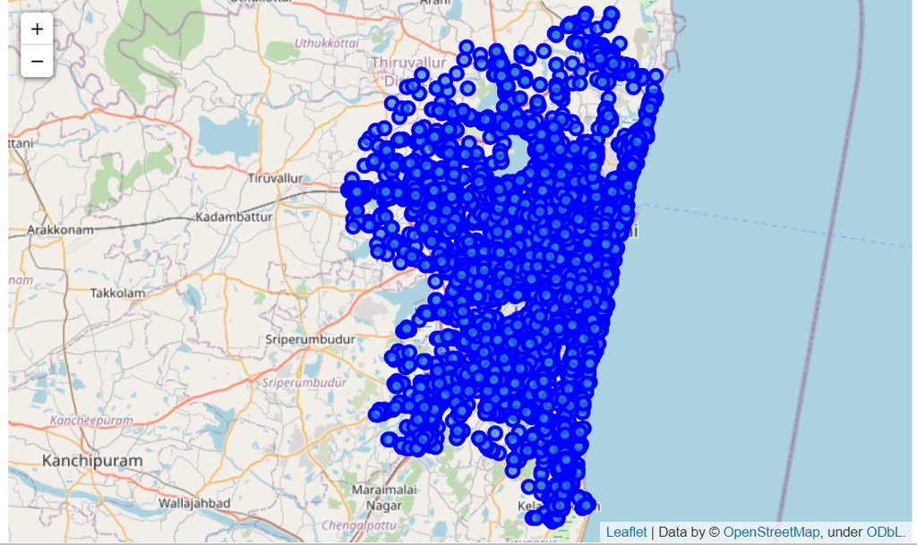

```python
# If exclude localities out of scope region, use below
#list_out = ['']
#df3_venues = df2_venues[~df2_venues.locality.isin(list_out)]
```

```python
df2_venues.info()
```

```
<class 'pandas.core.frame.DataFrame'>
RangeIndex: 7104 entries, 0 to 7103
Data columns (total 11 columns):
 #   Column         Non-Null Count  Dtype
---  ------         --------------  -----
 0   district       7104 non-null   object
 1   locality       7104 non-null   object
 2   name           7104 non-null   object
 3   latitude       7104 non-null   float64
 4   longitude      7104 non-null   float64
 5   types          7104 non-null   object
 6   price level    7104 non-null   object
 7   rating         7104 non-null   float64
 8   total ratings  7104 non-null   float64
 9   vicinity       7104 non-null   object
 10  category       7104 non-null   object
dtypes: float64(4), object(7)
memory usage: 610.6+ KB
```

```python
# Percentage of categories
df2_venues.groupby("category").count()["name"].sort_values(ascending=False) / len(df2_venues) * 100
```

```
category
school              19.496059
bakery              18.440315
governmentoffice    18.158784
salon               15.568694
gym                 13.893581
petrolbunk           8.840090
theatre              5.602477
Name: name, dtype: float64
```

```python
# Write to csv
#df2_venues.to_csv('df_all_venues.csv', index=False)
```

## Analysis

Cluster the neighborhoods and then analyze each of the clusters. The results will allow to identify similar neighbourhoods with the concentration of outlet type. Based on the occurrence of these outlet type in different neighbourhoods, we can decide on which neighbourhoods are most suitable to open the respective food outlets.

In particular, we will target those neighborhood that has less target outlets and no target outlets.

We will use One-Hot encoding which allows the representation of categorical data to be more expressive. Many machine learning algorithms cannot work with categorical data directly. The categories must be converted into numbers. In our case, venue category are expressed as the mean of the frequency of occurrence of each category.

```python
df_venues_onehot = pd.get_dummies(df2_venues[['category']], prefix="", prefix_sep="")
df_venues_onehot['locality'] = df2_venues['locality']
fixed_columns = ['locality'] + list(df_venues_onehot.columns.drop('locality'))
df_venues_onehot = df_venues_onehot[fixed_columns]

df_venues_onehot.head()
```

|  | locality | bakery | governmentoffice | gym | petrolbunk | salon | school | theatre |
| --- | --- | --- | --- | --- | --- | --- | --- | --- |
| 0 | Adambakkam | 0 | 0 | 0 | 0 | 0 | 1 | 0 |
| 1 | Adambakkam | 0 | 0 | 0 | 0 | 0 | 1 | 0 |
| 2 | Adambakkam | 0 | 0 | 0 | 0 | 0 | 1 | 0 |
| 3 | Adambakkam | 0 | 0 | 0 | 0 | 0 | 1 | 0 |
| 4 | Adambakkam | 0 | 0 | 0 | 0 | 0 | 1 | 0 |

```python
df_venues_onehot.shape
```

```
(7104, 8)
```

```python
df_venues_density = df_venues_onehot.groupby('locality').mean().reset_index()
df_venues_density.head()
```

|  | locality | bakery | governmentoffice | gym | petrolbunk | salon | school | theatre |
| --- | --- | --- | --- | --- | --- | --- | --- | --- |
| 0 | Adambakkam | 0.136364 | 0.160428 | 0.160428 | 0.112299 | 0.149733 | 0.149733 | 0.131016 |
| 1 | Adyar | 0.138249 | 0.138249 | 0.152074 | 0.138249 | 0.156682 | 0.152074 | 0.124424 |
| 2 | Alandur | 0.149254 | 0.134328 | 0.194030 | 0.074627 | 0.194030 | 0.134328 | 0.119403 |
| 3 | Alapakkam | 0.151079 | 0.147482 | 0.136691 | 0.136691 | 0.147482 | 0.147482 | 0.133094 |
| 4 | Alwarpet | 0.105528 | 0.155779 | 0.155779 | 0.130653 | 0.150754 | 0.145729 | 0.155779 |

```python
df_venues_density.shape
```

```
(144, 8)
```

Save dataframe to pickle file & Load dataframe from pickle file

```python
with open('df_venues_density.pkl', 'wb') as f:
    pickle.dump(df_venues_density, f)

with open('df_venues_density.pkl', 'rb') as f:
    df_venues_density = pickle.load(f)

df_venues_density.head()
```

|  | locality | bakery | governmentoffice | gym | petrolbunk | salon | school | theatre |
| --- | --- | --- | --- | --- | --- | --- | --- | --- |
| 0 | Adambakkam | 0.136364 | 0.160428 | 0.160428 | 0.112299 | 0.149733 | 0.149733 | 0.131016 |
| 1 | Adyar | 0.138249 | 0.138249 | 0.152074 | 0.138249 | 0.156682 | 0.152074 | 0.124424 |
| 2 | Alandur | 0.149254 | 0.134328 | 0.194030 | 0.074627 | 0.194030 | 0.134328 | 0.119403 |
| 3 | Alapakkam | 0.151079 | 0.147482 | 0.136691 | 0.136691 | 0.147482 | 0.147482 | 0.133094 |
| 4 | Alwarpet | 0.105528 | 0.155779 | 0.155779 | 0.130653 | 0.150754 | 0.145729 | 0.155779 |

Create a new dataframe to display the top venue categories for each neighborhood. We will utilize the below function to achieve our task.

```python
def return_most_common_venues(row, num_top_venues):
    row_categories = row.iloc[1:]
    row_categories_sorted = row_categories.sort_values(ascending=False)

    return row_categories_sorted.index.values[0:num_top_venues]
```

```python
num_top_venues = 5

indicators = ['st', 'nd', 'rd']

# create columns according to number of top venues
columns = ['locality']
for ind in np.arange(num_top_venues):
    try:
        columns.append('{}{} Most Common Venue'.format(ind+1, indicators[ind]))
    except:
        columns.append('{}th Most Common Venue'.format(ind+1))

# create a new dataframe
neighborhoods_venues_sorted = pd.DataFrame(columns=columns)
neighborhoods_venues_sorted['locality'] = df_venues_density['locality']

for ind in np.arange(df_venues_density.shape[0]):
    neighborhoods_venues_sorted.iloc[ind, 1:] = return_most_common_venues(df_venues_density.iloc[ind, :], num_top_venues)

neighborhoods_venues_sorted.head(10)
```

|  | locality | 1st Most Common Venue | 2nd Most Common Venue | 3rd Most Common Venue | 4th Most Common Venue | 5th Most Common Venue |
| --- | --- | --- | --- | --- | --- | --- |
| 0 | Adambakkam | governmentoffice | gym | salon | school | bakery |
| 1 | Adyar | salon | gym | school | bakery | governmentoffice |
| 2 | Alandur | gym | salon | bakery | governmentoffice | school |
| 3 | Alapakkam | bakery | governmentoffice | salon | school | gym |
| 4 | Alwarpet | governmentoffice | gym | theatre | salon | school |
| 5 | Alwarthirunagar | bakery | salon | governmentoffice | theatre | school |
| 6 | Ambattur | governmentoffice | gym | school | bakery | salon |
| 7 | Aminjikarai | governmentoffice | petrolbunk | school | gym | bakery |
| 8 | Anna Nagar | bakery | governmentoffice | gym | salon | school |
| 9 | Annanur | salon | school | bakery | governmentoffice | gym |

> Get Neighborhood without competing venues

```python
searchfor = ['bakery']

neighborhoods_venues_sorted[neighborhoods_venues_sorted.apply(lambda x: (~x.str.contains('|'.join(searchfor), case=True, regex=True)))].dropna().head()
```

|  | locality | 1st Most Common Venue | 2nd Most Common Venue | 3rd Most Common Venue | 4th Most Common Venue | 5th Most Common Venue |
| --- | --- | --- | --- | --- | --- | --- |
| 4 | Alwarpet | governmentoffice | gym | theatre | salon | school |
| 15 | Besant Nagar | school | governmentoffice | gym | petrolbunk | salon |
| 23 | Ekkaduthangal | governmentoffice | petrolbunk | gym | salon | theatre |
| 46 | Korukkupet | governmentoffice | school | salon | theatre | gym |
| 63 | Mandaveli | salon | gym | petrolbunk | school | theatre |

### Clustering neighbors

```python
df_venues_density.head()
```

|  | locality | bakery | governmentoffice | gym | petrolbunk | salon | school | theatre |
| --- | --- | --- | --- | --- | --- | --- | --- | --- |
| 0 | Adambakkam | 0.136364 | 0.160428 | 0.160428 | 0.112299 | 0.149733 | 0.149733 | 0.131016 |
| 1 | Adyar | 0.138249 | 0.138249 | 0.152074 | 0.138249 | 0.156682 | 0.152074 | 0.124424 |
| 2 | Alandur | 0.149254 | 0.134328 | 0.194030 | 0.074627 | 0.194030 | 0.134328 | 0.119403 |
| 3 | Alapakkam | 0.151079 | 0.147482 | 0.136691 | 0.136691 | 0.147482 | 0.147482 | 0.133094 |
| 4 | Alwarpet | 0.105528 | 0.155779 | 0.155779 | 0.130653 | 0.150754 | 0.145729 | 0.155779 |

```python
inertia = []
for i in range(2,10):
    kmeans = KMeans(n_clusters=i, random_state=0).fit(df_venues_density.drop(labels="locality", axis=1))
    inertia.append(kmeans.inertia_)
    score = silhouette_score(df_venues_density.drop(labels="locality", axis=1), kmeans.labels_, metric='euclidean')
    print(i,'Silhouetter Score: %.3f' % score)
```

```
2 Silhouetter Score: 0.354
3 Silhouetter Score: 0.384
4 Silhouetter Score: 0.402
5 Silhouetter Score: 0.438
6 Silhouetter Score: 0.371
7 Silhouetter Score: 0.372
8 Silhouetter Score: 0.380
9 Silhouetter Score: 0.381
```

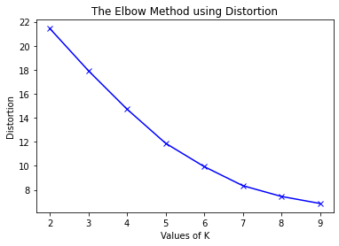

```python
plt.plot(range(2, 10), inertia, 'bx-')
plt.xlabel('Values of K')
plt.ylabel('Distortion')
plt.title('The Elbow Method using Distortion')
plt.show()
```

```python
kclusters = 5
kmeans = KMeans(n_clusters=kclusters, random_state=0).fit(df_venues_density.iloc[:,1:])
np.unique(kmeans.labels_, return_counts=True)
```

```
(array([0, 1, 2, 3, 4]), array([30, 98,  6,  4,  6], dtype=int64))
```

```python
# If exclude localities out of scope region, use below
list_out = []
df_locality = chennai_df[~chennai_df.Neighborhood.isin(list_out)]
```

```python
# Remove duplicate - Same locality
duplicate_venues = df_locality.groupby(['Neighborhood','Latitude','Longitude']).size().reset_index(name='count')
duplicate_venues[duplicate_venues['count']!=1]
```

|  | Neighborhood | Latitude | Longitude | count |
| --- | --- | --- | --- | --- |

```python
df1_locality = df_locality.drop_duplicates(['Neighborhood','Latitude','Longitude'], ignore_index=True)
```

```python
# Venue density
df_venues_density
```

|  | locality | bakery | governmentoffice | gym | petrolbunk | salon | school | theatre |
| --- | --- | --- | --- | --- | --- | --- | --- | --- |
| 0 | Adambakkam | 0.136364 | 0.160428 | 0.160428 | 0.112299 | 0.149733 | 0.149733 | 0.131016 |
| 1 | Adyar | 0.138249 | 0.138249 | 0.152074 | 0.138249 | 0.156682 | 0.152074 | 0.124424 |
| 2 | Alandur | 0.149254 | 0.134328 | 0.194030 | 0.074627 | 0.194030 | 0.134328 | 0.119403 |
| 3 | Alapakkam | 0.151079 | 0.147482 | 0.136691 | 0.136691 | 0.147482 | 0.147482 | 0.133094 |
| 4 | Alwarpet | 0.105528 | 0.155779 | 0.155779 | 0.130653 | 0.150754 | 0.145729 | 0.155779 |
| ... | ... | ... | ... | ... | ... | ... | ... | ... |
| 139 | Villivakkam | 0.000000 | 1.000000 | 0.000000 | 0.000000 | 0.000000 | 0.000000 | 0.000000 |
| 140 | Virugambakkam | 0.000000 | 0.500000 | 0.000000 | 0.000000 | 0.500000 | 0.000000 | 0.000000 |
| 141 | Vyasarpadi | 0.000000 | 0.000000 | 0.000000 | 0.000000 | 1.000000 | 0.000000 | 0.000000 |
| 142 | Washermanpet | 0.000000 | 0.000000 | 0.000000 | 0.000000 | 0.000000 | 0.500000 | 0.500000 |
| 143 | West Mambalam | 0.000000 | 1.000000 | 0.000000 | 0.000000 | 0.000000 | 0.000000 | 0.000000 |

144 rows × 8 columns

```python
# Join Venue density with neighborhoods
df1_locality.merge(df_venues_density, left_on='Neighborhood',right_on='locality', how='right').reset_index(drop=True)
```

|  | Neighborhood | Latitude | Longitude | District | locality | bakery | governmentoffice | gym | petrolbunk | salon | school | theatre |
| --- | --- | --- | --- | --- | --- | --- | --- | --- | --- | --- | --- | --- |
| 0 | Adambakkam | 12.99192 | 80.20603 | Chennai | Adambakkam | 0.136364 | 0.160428 | 0.160428 | 0.112299 | 0.149733 | 0.149733 | 0.131016 |
| 1 | Adyar | 13.00303 | 80.25187 | Chennai | Adyar | 0.138249 | 0.138249 | 0.152074 | 0.138249 | 0.156682 | 0.152074 | 0.124424 |
| 2 | Alandur | 13.00013 | 80.20049 | Chennai | Alandur | 0.149254 | 0.134328 | 0.194030 | 0.074627 | 0.194030 | 0.134328 | 0.119403 |
| 3 | Alapakkam | 13.04613 | 80.16501 | Chennai | Alapakkam | 0.151079 | 0.147482 | 0.136691 | 0.136691 | 0.147482 | 0.147482 | 0.133094 |
| 4 | Alwarpet | 13.03471 | 80.25416 | Chennai | Alwarpet | 0.105528 | 0.155779 | 0.155779 | 0.130653 | 0.150754 | 0.145729 | 0.155779 |
| ... | ... | ... | ... | ... | ... | ... | ... | ... | ... | ... | ... | ... |
| 139 | Villivakkam | 13.10491 | 80.20604 | Chennai | Villivakkam | 0.000000 | 1.000000 | 0.000000 | 0.000000 | 0.000000 | 0.000000 | 0.000000 |
| 140 | Virugambakkam | 13.05591 | 80.19347 | Chennai | Virugambakkam | 0.000000 | 0.500000 | 0.000000 | 0.000000 | 0.500000 | 0.000000 | 0.000000 |
| 141 | Vyasarpadi | 13.11778 | 80.25168 | Chennai | Vyasarpadi | 0.000000 | 0.000000 | 0.000000 | 0.000000 | 1.000000 | 0.000000 | 0.000000 |
| 142 | Washermanpet | 13.1095 | 80.28701 | Chennai | Washermanpet | 0.000000 | 0.000000 | 0.000000 | 0.000000 | 0.000000 | 0.500000 | 0.500000 |
| 143 | West Mambalam | 13.03868 | 80.22285 | Chennai | West Mambalam | 0.000000 | 1.000000 | 0.000000 | 0.000000 | 0.000000 | 0.000000 | 0.000000 |

144 rows × 12 columns

```python
# Add cluster label
df1_venues_density = df1_locality.merge(df_venues_density, left_on='Neighborhood',right_on='locality', how='inner').reset_index(drop=True)
df1_venues_density.insert(3, 'Cluster Labels', kmeans.labels_)

df1_venues_density.head()
```

|  | Neighborhood | Latitude | Longitude | Cluster Labels | District | locality | bakery | governmentoffice | gym | petrolbunk | salon | school | theatre |
| --- | --- | --- | --- | --- | --- | --- | --- | --- | --- | --- | --- | --- | --- |
| 0 | Adambakkam | 12.99192 | 80.20603 | 1 | Chennai | Adambakkam | 0.136364 | 0.160428 | 0.160428 | 0.112299 | 0.149733 | 0.149733 | 0.131016 |
| 1 | Adyar | 13.00303 | 80.25187 | 1 | Chennai | Adyar | 0.138249 | 0.138249 | 0.152074 | 0.138249 | 0.156682 | 0.152074 | 0.124424 |
| 2 | Alandur | 13.00013 | 80.20049 | 1 | Chennai | Alandur | 0.149254 | 0.134328 | 0.194030 | 0.074627 | 0.194030 | 0.134328 | 0.119403 |
| 3 | Alapakkam | 13.04613 | 80.16501 | 1 | Chennai | Alapakkam | 0.151079 | 0.147482 | 0.136691 | 0.136691 | 0.147482 | 0.147482 | 0.133094 |
| 4 | Alwarpet | 13.03471 | 80.25416 | 1 | Chennai | Alwarpet | 0.105528 | 0.155779 | 0.155779 | 0.130653 | 0.150754 | 0.145729 | 0.155779 |

```python
# create map
map_clusters = folium.Map(location=[latitude, longitude], zoom_start=11)

# set color for the clusters
color = ["red", "green", "blue", "darkgoldenrod","black","orange"]

# add markers to the map
folium.Marker([latitude, longitude], popup="Chennai city").add_to(map_clusters)
markers_colors = []
for lat, lon, poi, cluster in zip(df1_venues_density['Latitude'], df1_venues_density['Longitude'], df1_venues_density['Neighborhood'], df1_venues_density['Cluster Labels'].astype(int)):
    label = folium.Popup(str(poi) + ' Cluster ' + str(cluster), parse_html=True)
    folium.CircleMarker(
        [lat, lon],
        radius=4,
        popup=label,
        color=color[cluster],
        fill=True,
        fill_opacity=0.7).add_to(map_clusters)

# Add Categorical Legend
legend_html = """
<div style="position:fixed;
    background: white;
    top: 10px;
    right: 10px;
    width: 100px;
    height: 100px;
    border:2px solid grey;
    z-index: 9999;
    font-size:14px;">
    &nbsp;<i class="fa fa-circle fa-1x" style="color:{}"></i>&nbsp;Cluster 0<br>
    &nbsp;<i class="fa fa-circle fa-1x" style="color:{}"></i>&nbsp;Cluster 1<br>
    &nbsp;<i class="fa fa-circle fa-1x" style="color:{}"></i>&nbsp;Cluster 2<br>
    &nbsp;<i class="fa fa-circle fa-1x" style="color:{}"></i>&nbsp;Cluster 3<br>
    &nbsp;<i class="fa fa-circle fa-1x" style="color:{}"></i>&nbsp;Cluster 4<br>
</div>""".format(*color)
map_clusters.get_root().html.add_child(folium.Element(legend_html))
```

```
<branca.element.Element at 0x26868242670>
```

```python
#map_clusters
```

[figure not shown]

### Cluster Analysis

Each of the clusters are analyzed separately to find the opportunity of opening a new outlets with respect to each type, within each of the cluster. Each of the clusters are thoroughly examined to uncover some useful insights about the outlets and general venue density.

```python
locations = ['bakery','governmentoffice','gym','petrolbunk','salon','school','theatre']
```

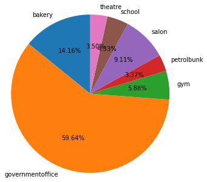

```python
cluster_df = df1_venues_density.loc[df1_venues_density['Cluster Labels'] == 0] \
                               .drop(labels=['Latitude', 'Longitude', 'Cluster Labels'], axis=1) \
                               .reset_index(drop=True)

x = cluster_df[locations].sum().values
labels = cluster_df[locations].sum().index
plt.pie(x=x, labels=labels, radius=1.5, startangle=90, autopct="%.2f%%");
```

#### Function for cluster analysis

```python
# Cluster number
clusternum = 0

def cluster_analysis(df1_venues_density,clusternum):
    # Outlet fraction of all outlets
    print("\nOutlet fraction of all outlets")
    cluster_outlet = df1_venues_density.loc[df1_venues_density['Cluster Labels'] == clusternum].drop(labels=['Latitude', 'Longitude', 'Cluster Labels'], axis=1).reset_index(drop=True)
    cluster_outlet.insert(1, 'Outlet fraction', cluster_outlet.sum(axis=1,numeric_only=True))
    r3 = cluster_outlet.head()
    display(r3)

    # Outlet fraction of target outlets
    print("\nOutlet fraction of target outlets")
    #locations = ['bakery','governmentoffice','gym','petrolbunk','salon','school','theatre']
    target_outlet = ['bakery']
    r4 = cluster_outlet[['Neighborhood', 'Outlet fraction'] + target_outlet].head()
    display(r4)

    # Outlet count in bins across outlet fraction
    print("\nTarget outlet count in bins")
    cluster_outlet1 = cluster_outlet
    cluster_outlet1['Outlet_fraction'] = pd.cut(cluster_outlet1['Outlet fraction'], [0, 0.25, 0.5, 0.75, 1],include_lowest=True)

    g = cluster_outlet1['Outlet_fraction']
    r5 = pd.concat([g.value_counts(),
    g.value_counts(normalize=True).mul(100).round(0)],axis=1,keys=('counts','percentage'))
    display(r5)


    # Portion of outets in cluster as pie chart
    print("\nPortion of outets in cluster as pie chart")
    cluster_df = df1_venues_density.loc[df1_venues_density['Cluster Labels'] == clusternum] \
                                   .drop(labels=['Latitude', 'Longitude', 'Cluster Labels'], axis=1) \
                                   .reset_index(drop=True)

    x = cluster_df[locations].sum().values
    labels = cluster_df[locations].sum().index
    plt.pie(x=x, labels=labels, radius=1.5, startangle=90, autopct="%.2f%%");
    print('Total neighbourhoods in cluster :',len(cluster_df))
    #display(cluster_df[['Neighborhood','District']])
```

#### Cluster 0

```
Outlet fraction of all outlets
```

|  | Neighborhood | Outlet fraction | District | locality | bakery | governmentoffice | gym | petrolbunk | salon | school | theatre |
| --- | --- | --- | --- | --- | --- | --- | --- | --- | --- | --- | --- |
| 0 | Arumbakkam | 1.0 | Chennai | Arumbakkam | 0.000000 | 1.000000 | 0.000000 | 0.000000 | 0.000000 | 0.000000 | 0.000000 |
| 1 | Choolai | 1.0 | Chennai | Choolai | 0.000000 | 0.666667 | 0.000000 | 0.000000 | 0.333333 | 0.000000 | 0.000000 |
| 2 | Ekkaduthangal | 1.0 | Chennai | Ekkaduthangal | 0.000000 | 0.615385 | 0.076923 | 0.153846 | 0.076923 | 0.000000 | 0.076923 |
| 3 | Gopalapuram | 1.0 | Chennai | Gopalapuram | 0.500000 | 0.500000 | 0.000000 | 0.000000 | 0.000000 | 0.000000 | 0.000000 |
| 4 | Injambakkam | 1.0 | Chennai | Injambakkam | 0.184906 | 0.200000 | 0.177358 | 0.056604 | 0.169811 | 0.173585 | 0.037736 |

```
Outlet fraction of target outlets
```

|  | Neighborhood | Outlet fraction | bakery |
| --- | --- | --- | --- |
| 0 | Arumbakkam | 1.0 | 0.000000 |
| 1 | Choolai | 1.0 | 0.000000 |
| 2 | Ekkaduthangal | 1.0 | 0.000000 |
| 3 | Gopalapuram | 1.0 | 0.500000 |
| 4 | Injambakkam | 1.0 | 0.184906 |

```
Target outlet count in bins
```

|  | counts | percentage |
| --- | --- | --- |
| (0.75, 1.0] | 29 | 100.0 |
| (-0.001, 0.25] | 0 | 0.0 |
| (0.25, 0.5] | 0 | 0.0 |
| (0.5, 0.75] | 0 | 0.0 |

```
Portion of outets in cluster as pie chart
Total neighbourhoods in cluster : 30
```

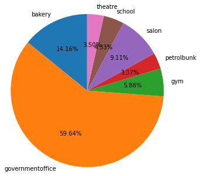

```python
cluster_analysis(df1_venues_density,0)
```

#### Cluster 1

```
Outlet fraction of all outlets
```

|  | Neighborhood | Outlet fraction | District | locality | bakery | governmentoffice | gym | petrolbunk | salon | school | theatre |
| --- | --- | --- | --- | --- | --- | --- | --- | --- | --- | --- | --- |
| 0 | Adambakkam | 1.0 | Chennai | Adambakkam | 0.136364 | 0.160428 | 0.160428 | 0.112299 | 0.149733 | 0.149733 | 0.131016 |
| 1 | Adyar | 1.0 | Chennai | Adyar | 0.138249 | 0.138249 | 0.152074 | 0.138249 | 0.156682 | 0.152074 | 0.124424 |
| 2 | Alandur | 1.0 | Chennai | Alandur | 0.149254 | 0.134328 | 0.194030 | 0.074627 | 0.194030 | 0.134328 | 0.119403 |
| 3 | Alapakkam | 1.0 | Chennai | Alapakkam | 0.151079 | 0.147482 | 0.136691 | 0.136691 | 0.147482 | 0.147482 | 0.133094 |
| 4 | Alwarpet | 1.0 | Chennai | Alwarpet | 0.105528 | 0.155779 | 0.155779 | 0.130653 | 0.150754 | 0.145729 | 0.155779 |

```
Outlet fraction of target outlets
```

|  | Neighborhood | Outlet fraction | bakery |
| --- | --- | --- | --- |
| 0 | Adambakkam | 1.0 | 0.136364 |
| 1 | Adyar | 1.0 | 0.138249 |
| 2 | Alandur | 1.0 | 0.149254 |
| 3 | Alapakkam | 1.0 | 0.151079 |
| 4 | Alwarpet | 1.0 | 0.105528 |

```
Target outlet count in bins
```

|  | counts | percentage |
| --- | --- | --- |
| (0.75, 1.0] | 97 | 100.0 |
| (-0.001, 0.25] | 0 | 0.0 |
| (0.25, 0.5] | 0 | 0.0 |
| (0.5, 0.75] | 0 | 0.0 |

```
Portion of outets in cluster as pie chart
Total neighbourhoods in cluster : 98
```

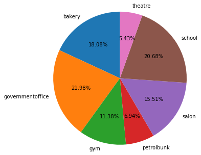

```python
cluster_analysis(df1_venues_density,1)
```

#### Cluster 2

```
Outlet fraction of all outlets
```

|  | Neighborhood | Outlet fraction | District | locality | bakery | governmentoffice | gym | petrolbunk | salon | school | theatre |
| --- | --- | --- | --- | --- | --- | --- | --- | --- | --- | --- | --- |
| 0 | Pammal | 1.0 | Chennai | Pammal | 0.090909 | 0.090909 | 0.000000 | 0.090909 | 0.545455 | 0.181818 | 0.0 |
| 1 | Parry's Corner | 1.0 | Chennai | Parry's Corner | 0.000000 | 0.333333 | 0.000000 | 0.000000 | 0.666667 | 0.000000 | 0.0 |
| 2 | Royapettah | 1.0 | Chennai | Royapettah | 0.000000 | 0.000000 | 0.000000 | 0.000000 | 1.000000 | 0.000000 | 0.0 |
| 3 | Sowcarpet | 1.0 | Chennai | Sowcarpet | 0.000000 | 0.000000 | 0.000000 | 0.000000 | 1.000000 | 0.000000 | 0.0 |
| 4 | Vandalur | 1.0 | Chennai | Vandalur | 0.272727 | 0.272727 | 0.090909 | 0.000000 | 0.272727 | 0.090909 | 0.0 |

```
Outlet fraction of target outlets
```

|  | Neighborhood | Outlet fraction | bakery |
| --- | --- | --- | --- |
| 0 | Pammal | 1.0 | 0.090909 |
| 1 | Parry's Corner | 1.0 | 0.000000 |
| 2 | Royapettah | 1.0 | 0.000000 |
| 3 | Sowcarpet | 1.0 | 0.000000 |
| 4 | Vandalur | 1.0 | 0.272727 |

```
Target outlet count in bins
```

|  | counts | percentage |
| --- | --- | --- |
| (0.75, 1.0] | 6 | 100.0 |
| (-0.001, 0.25] | 0 | 0.0 |
| (0.25, 0.5] | 0 | 0.0 |
| (0.5, 0.75] | 0 | 0.0 |

```
Portion of outets in cluster as pie chart
Total neighbourhoods in cluster : 6
```

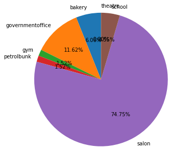

```python
cluster_analysis(df1_venues_density,2)
```

#### Cluster 3

```
Outlet fraction of all outlets
```

|  | Neighborhood | Outlet fraction | District | locality | bakery | governmentoffice | gym | petrolbunk | salon | school | theatre |
| --- | --- | --- | --- | --- | --- | --- | --- | --- | --- | --- | --- |
| 0 | Ashok Nagar | 1.0 | Chennai | Ashok Nagar | 0.0 | 0.0 | 1.0 | 0.0 | 0.0 | 0.0 | 0.0 |
| 1 | Government Estate | 1.0 | Chennai | Government Estate | 0.0 | 0.0 | 1.0 | 0.0 | 0.0 | 0.0 | 0.0 |
| 2 | Nolambur | 1.0 | Chennai | Nolambur | 0.0 | 0.0 | 1.0 | 0.0 | 0.0 | 0.0 | 0.0 |
| 3 | Pudupet | 1.0 | Chennai | Pudupet | 0.0 | 0.0 | 0.5 | 0.5 | 0.0 | 0.0 | 0.0 |

```
Outlet fraction of target outlets
```

|  | Neighborhood | Outlet fraction | bakery |
| --- | --- | --- | --- |
| 0 | Ashok Nagar | 1.0 | 0.0 |
| 1 | Government Estate | 1.0 | 0.0 |
| 2 | Nolambur | 1.0 | 0.0 |
| 3 | Pudupet | 1.0 | 0.0 |

```
Target outlet count in bins
```

|  | counts | percentage |
| --- | --- | --- |
| (0.75, 1.0] | 4 | 100.0 |
| (-0.001, 0.25] | 0 | 0.0 |
| (0.25, 0.5] | 0 | 0.0 |
| (0.5, 0.75] | 0 | 0.0 |

```
Portion of outets in cluster as pie chart
Total neighbourhoods in cluster : 4
```

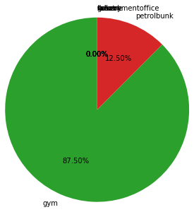

```python
cluster_analysis(df1_venues_density,3)
```

#### Cluster 4

```
Outlet fraction of all outlets
```

|  | Neighborhood | Outlet fraction | District | locality | bakery | governmentoffice | gym | petrolbunk | salon | school | theatre |
| --- | --- | --- | --- | --- | --- | --- | --- | --- | --- | --- | --- |
| 0 | Guindy | 1.0 | Chennai | Guindy | 0.666667 | 0.333333 | 0.000000 | 0.000000 | 0.000000 | 0.000000 | 0.0 |
| 1 | Jafferkhanpet | 1.0 | Chennai | Jafferkhanpet | 1.000000 | 0.000000 | 0.000000 | 0.000000 | 0.000000 | 0.000000 | 0.0 |
| 2 | Kottur | 1.0 | Chennai | Kottur | 0.291139 | 0.265823 | 0.113924 | 0.037975 | 0.063291 | 0.227848 | 0.0 |
| 3 | Moulivakkam | 1.0 | Chennai | Moulivakkam | 0.100000 | 0.500000 | 0.000000 | 0.000000 | 0.200000 | 0.200000 | 0.0 |
| 4 | Park Town | 1.0 | Chennai | Park Town | 1.000000 | 0.000000 | 0.000000 | 0.000000 | 0.000000 | 0.000000 | 0.0 |

```
Outlet fraction of target outlets
```

|  | Neighborhood | Outlet fraction | bakery |
| --- | --- | --- | --- |
| 0 | Guindy | 1.0 | 0.666667 |
| 1 | Jafferkhanpet | 1.0 | 1.000000 |
| 2 | Kottur | 1.0 | 0.291139 |
| 3 | Moulivakkam | 1.0 | 0.100000 |
| 4 | Park Town | 1.0 | 1.000000 |

```
Target outlet count in bins
```

|  | counts | percentage |
| --- | --- | --- |
| (0.75, 1.0] | 6 | 100.0 |
| (-0.001, 0.25] | 0 | 0.0 |
| (0.25, 0.5] | 0 | 0.0 |
| (0.5, 0.75] | 0 | 0.0 |

```
Portion of outets in cluster as pie chart
Total neighbourhoods in cluster : 6
```

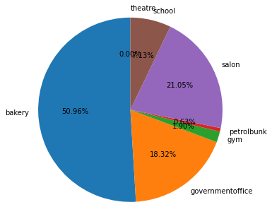

```python
cluster_analysis(df1_venues_density,4)
```

## Results

The summary of our analysis are,

- **Cluster 0** - Bakery comprises 14% of 30 neighboorhoods
- **Cluster 1** - Bakery comprises 18% of 98 neighboorhoods
- **Cluster 2** - Bakery comprises 6% of 6 neighboorhoods
- **Cluster 3** - Bakery comprises 0% of 4 neighboorhoods
- **Cluster 4** - Bakery comprises 50% of 6 neighboorhoods

We can also apply the same approach for the larger dataset. This approach can also be applied to identify promising location for shopping malls, movie theaters and other related business. In this project, we considered only one factor, that is, venue density distribution. There are some other most useful factors like population and income of residents, real estate availability, surrounding localities, financial report etc., can be really helpful to further narrow down the choice of selecting the optimal location by the stakeholders based on specific characteristics of neighborhoods and locations.

Final decision on selecting the optimal location for the outlet will be made by stakeholders based on specific characteristics of neighborhoods and locations in every area, taking additional factors into consideration that are discussed above.